# fakenews_seq_classification

## Bussiness Issue

**Defining Fake News**

Fake news pertains to the intentional dissemination of false or deceptive assertions as news, with these claims being deliberately crafted to mislead.

**Evolution of News and the Digital Medium**

The progression of news media can be traced from traditional sources like newspapers and magazines to digital platforms encompassing online news sites, blogs, social media streams, and various news mobile applications. The surge in social media and mobile platform use has allowed news outlets to furnish timely updates to their audience, resulting in the swift acquisition of current news.

This transformation has empowered consumers to access up-to-the-minute news effortlessly. Consequently, these digital platforms have gained substantial influence due to their global accessibility, fostering discussions, idea sharing, and debates on matters spanning democracy, education, health, research, and history.

Nevertheless, alongside these benefits, false and misleading news articles have proliferated on digital platforms, frequently employed for ulterior motives such as political and financial gains, the cultivation of biased viewpoints, psychological manipulation, and the propagation of nonsensical content.

**Proposed Solutions**

Hence, the need to distinguish authentic news from fake news is paramount. One approach involves the expertise of professionals and fact-checking for each news piece, albeit time-consuming and skill-intensive. Alternatively, automated detection of fake news can be achieved through Machine Learning and Artificial Intelligence techniques. As online news content takes diverse forms—such as text, videos, and audio—we will focus on textual news. With the advancements in Natural Language Processing, identifying deceitful and counterfeit content within articles or sentences is now feasible.

Extensive research and experimentation are underway to address fake news across all media formats (text, video, and audio). In our study, we utilized Deep Learning's Sequence to Sequence programming to classify unreliable news articles as fake news

```python
### Import all library
import pandas as pd
import numpy as np
from sklearn.model_selection import train_test_split
import matplotlib.pyplot as plt
import seaborn as sns
from pathlib import Path
```

```python
def read_data(filename,**kwargs):
    raw_data=pd.read_csv(filename,**kwargs)
    return raw_data
```

```python
# Setup Directory Path
print("C:\\Users\\sekka\\Downloads\\FakeNewsProject\\FakeNews")
```

```
C:\Users\sekka\Downloads\FakeNewsProject\FakeNews
```

## Data Understanding

```python
#### READ DATASTS
news_df= read_data("../input/train.csv")
submit_test = read_data('../input/test.csv')
submit_label = read_data('../input/submit.csv')
submit_test['label'] = submit_label.label
print(" Shape of News data :: ", news_df.shape)
print(" News data columns", news_df.columns)
print(" Test columns", submit_test.columns)
news_df.head()
```

```
 Shape of News data ::  (20800, 5)
 News data columns Index(['id', 'title', 'author', 'text', 'label'], dtype='object')
 Test columns Index(['id', 'title', 'author', 'text', 'label'], dtype='object')
```

|  | id | title | author | text | label |
| --- | --- | --- | --- | --- | --- |
| 0 | 0 | House Dem Aide: We Didn’t Even See Comey’s Let... | Darrell Lucus | House Dem Aide: We Didn’t Even See Comey’s Let... | 1 |
| 1 | 1 | FLYNN: Hillary Clinton, Big Woman on Campus - ... | Daniel J. Flynn | Ever get the feeling your life circles the rou... | 0 |
| 2 | 2 | Why the Truth Might Get You Fired | Consortiumnews.com | Why the Truth Might Get You Fired October 29, ... | 1 |
| 3 | 3 | 15 Civilians Killed In Single US Airstrike Hav... | Jessica Purkiss | Videos 15 Civilians Killed In Single US Airstr... | 1 |
| 4 | 4 | Iranian woman jailed for fictional unpublished... | Howard Portnoy | Print \nAn Iranian woman has been sentenced to... | 1 |

```python
submit_test.head()
```

|  | id | title | author | text | label |
| --- | --- | --- | --- | --- | --- |
| 0 | 20800 | Specter of Trump Loosens Tongues, if Not Purse... | David Streitfeld | PALO ALTO, Calif. — After years of scorning... | 0 |
| 1 | 20801 | Russian warships ready to strike terrorists ne... | NaN | Russian warships ready to strike terrorists ne... | 1 |
| 2 | 20802 | #NoDAPL: Native American Leaders Vow to Stay A... | Common Dreams | Videos #NoDAPL: Native American Leaders Vow to... | 0 |
| 3 | 20803 | Tim Tebow Will Attempt Another Comeback, This ... | Daniel Victor | If at first you don’t succeed, try a different... | 1 |
| 4 | 20804 | Keiser Report: Meme Wars (E995) | Truth Broadcast Network | 42 mins ago 1 Views 0 Comments 0 Likes 'For th... | 1 |

```python
#Text Word startistics: min.mean, max and interquartile range
text_len = news_df.text.str.split().str.len()
text_len.describe()
```

```
count    20761.000000
mean       760.308126
std        869.525988
min          0.000000
25%        269.000000
50%        556.000000
75%       1052.000000
max      24234.000000
Name: text, dtype: float64
```

```python
#Title startistics
title_len = news_df.title.str.split().str.len()
title_len.describe()
```

```
count    20242.000000
mean        12.420709
std          4.098735
min          1.000000
25%         10.000000
50%         13.000000
75%         15.000000
max         72.000000
Name: title, dtype: float64
```

From following columns ['id', 'title', 'author', 'text', 'label'] we will not include id and author.

**Our experiment would be with both text and title together**

#### Count plot for both labels are

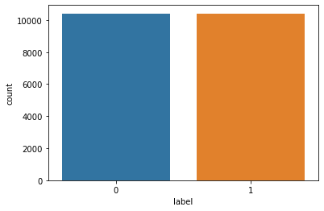

```python
sns.countplot(x="label", data=news_df)
plt.show()
```

## Clean Datasets:

- Drop unused row and columns
- Null value imputation
- Remove special characters
- Remove stop words

```python
## Constants Used for cleaning the datasets
column_names = ['id', 'title', 'author', 'text', 'label']
remove_columns = ['id','author']
categorical_features = []
target_col = ['label']
text_features = ['title', 'text']
```

```python
## Clean Datasets
import nltk
from nltk.corpus import stopwords
#nltk.download('stopwords')
import re
from nltk.corpus import stopwords
from nltk.stem.porter import PorterStemmer
from collections import Counter

ps = PorterStemmer()
wnl = nltk.stem.WordNetLemmatizer()

stop_words = stopwords.words('english')
stopwords_dict = Counter(stop_words)

# Removed unused clumns
def remove_unused_columns(df,column_names=remove_columns):
    df = df.drop(column_names,axis=1)
    return df

# Impute null values with None
def null_processing(feature_df):
    for col in text_features:
        feature_df.loc[feature_df[col].isnull(), col] = "None"
    return feature_df

def clean_datasets(df):
    # remove unused column
    df = remove_unused_columns(df)
    #impute null values
    df = null_processing(df)
    return df

## Cleaning text from unused characters
def clean_text(text):
    text = str(text).replace(r'http[\w:/\.]+', ' ')  # removing urls
    text = str(text).replace(r'[^\.\w\s]', ' ')  # remove everything but characters and punctuation
    text = str(text).replace('[^a-zA-Z]', ' ')
    text = str(text).replace(r'\s\s+', ' ')
    text = text.lower().strip()
    #text = ' '.join(text)
    return text

## Nltk Preprocessing include:
# Stop words,
# Stemming and
# Lemmetization
# For our project we use only Stop word removal
def nltk_preprocesing(text):
    text = clean_text(text)
    wordlist = re.sub(r'[^\w\s]', '', text).split()
    #text = ' '.join([word for word in wordlist if word not in stopwords_dict])
    #text = [ps.stem(word) for word in wordlist if not word in stopwords_dict]
    text = ' '.join([wnl.lemmatize(word) for word in wordlist if word not in stopwords_dict])
    return  text


df = clean_datasets(news_df)
df_test = clean_datasets(submit_test)

df["text"] = df.text.apply(nltk_preprocesing)
df_test["text"] = df_test.text.apply(nltk_preprocesing)

df["title"] = df.title.apply(nltk_preprocesing)
df_test["title"] = df_test.title.apply(nltk_preprocesing)
```

```python
df.head()
```

|  | title | text | label |
| --- | --- | --- | --- |
| 0 | house dem aide didnt even see comeys letter ja... | house dem aide didnt even see comeys letter ja... | 1 |
| 1 | flynn hillary clinton big woman campus breitbart | ever get feeling life circle roundabout rather... | 0 |
| 2 | truth might get fired | truth might get fired october 29 2016 tension ... | 1 |
| 3 | 15 civilian killed single u airstrike identified | video 15 civilian killed single u airstrike id... | 1 |
| 4 | iranian woman jailed fictional unpublished sto... | print iranian woman sentenced six year prison ... | 1 |

## Explorative Data Analysis

- Univariate Analysis: Statistical Analysis of Text, Word cloud
- Bivariate Analysis : Bigram and Trigram

### Single word word cloud

Most frequent word appear with Bold and bigger font.

#### Word cloud for all word in datasets

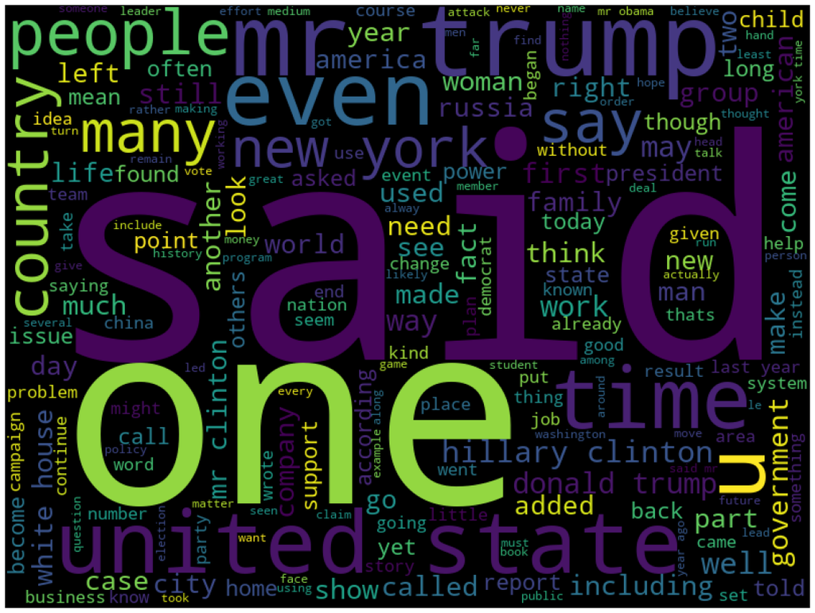

```python
from wordcloud import WordCloud, STOPWORDS
import matplotlib.pyplot as plt

wordcloud = WordCloud( background_color='black', width=800, height=600)

text_cloud = wordcloud.generate(' '.join(df['text']))

plt.figure(figsize=(20,30))
plt.imshow(text_cloud)
plt.axis('off')
plt.show()
```

### Word cloud for True label news only

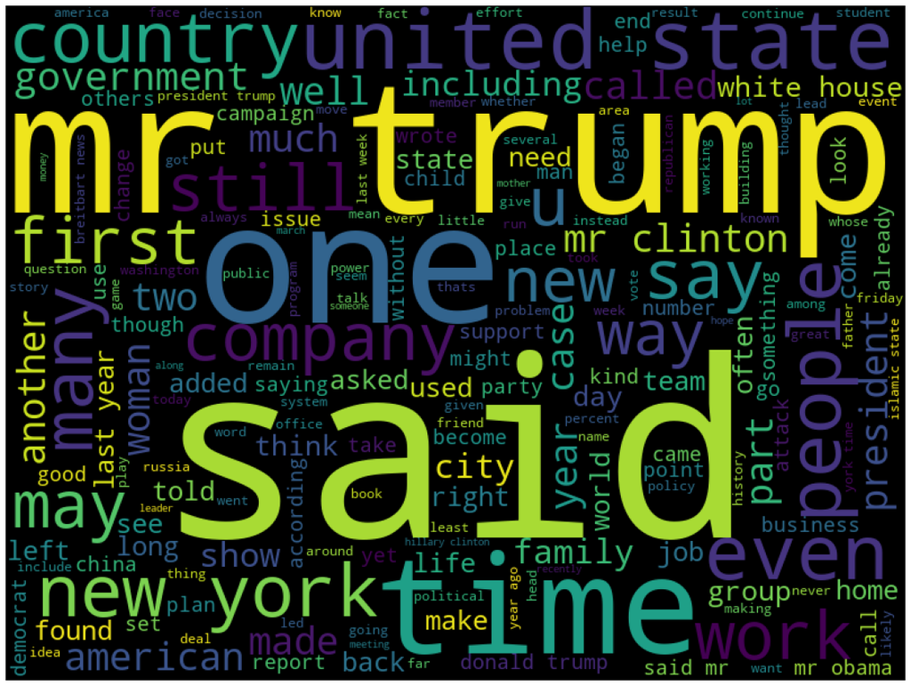

```python
true_news = ' '.join(df[df['label']==0]['text'])
wc = wordcloud.generate(true_news)
plt.figure(figsize=(20,30))
plt.imshow(wc)
plt.axis('off')
plt.show()
```

### Word cloud for Fake label news only

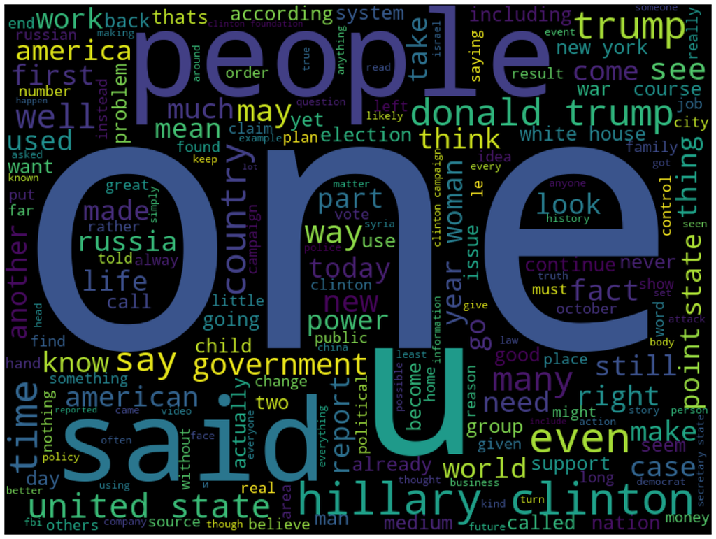

```python
fake_news = ' '.join(df[df['label']==1]['text'])
wc= wordcloud.generate(fake_news)
plt.figure(figsize=(20,30))
plt.imshow(wc)
plt.axis('off')
plt.show()
```

### Most frequent Bigram(Two word combination) of True label

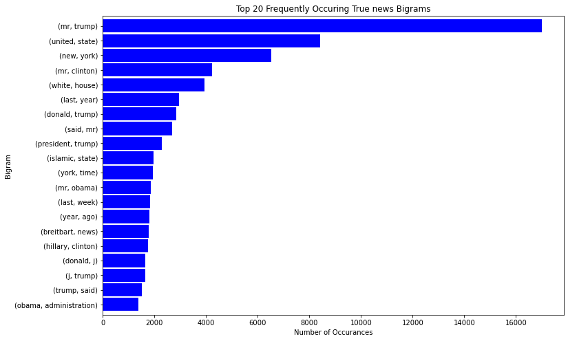

```python
true_bigrams = (pd.Series(nltk.ngrams(true_news.split(), 2)).value_counts())[:20]
true_bigrams.sort_values().plot.barh(color='blue', width=.9, figsize=(12, 8))
plt.title('Top 20 Frequently Occuring True news Bigrams')
plt.ylabel('Bigram')
plt.xlabel('Number of Occurances')
plt.show()
```

### Most frequent Bigram(Two word combination) of Fake label

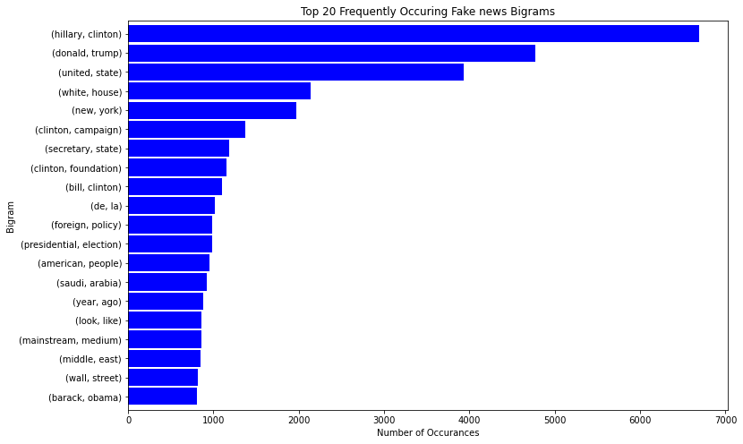

```python
fake_bigrams = (pd.Series(nltk.ngrams(fake_news.split(), 2)).value_counts())[:20]
fake_bigrams.sort_values().plot.barh(color='blue', width=.9, figsize=(12, 8))
plt.title('Top 20 Frequently Occuring Fake news Bigrams')
plt.ylabel('Bigram')
plt.xlabel('Number of Occurances')
plt.show()
```

### Most frequent Trigram(Three word combination) of True label

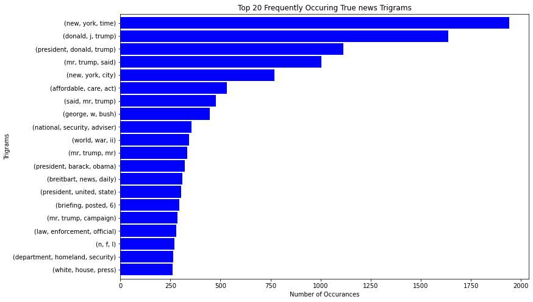

```python
true_bigrams = (pd.Series(nltk.ngrams(true_news.split(), 3)).value_counts())[:20]
true_bigrams.sort_values().plot.barh(color='blue', width=.9, figsize=(12, 8))
plt.title('Top 20 Frequently Occuring True news Trigrams')
plt.ylabel('Trigrams')
plt.xlabel('Number of Occurances')
plt.show()
```

### Most frequent Trigram(Three word combination) of Fake label

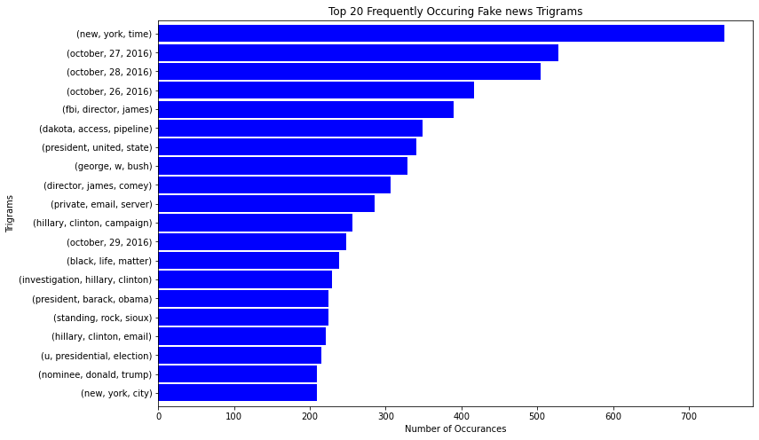

```python
fake_bigrams = (pd.Series(nltk.ngrams(fake_news.split(), 3)).value_counts())[:20]
fake_bigrams.sort_values().plot.barh(color='blue', width=.9, figsize=(12, 8))
plt.title('Top 20 Frequently Occuring Fake news Trigrams')
plt.ylabel('Trigrams')
plt.xlabel('Number of Occurances')
plt.show()
```

#### Hence from Word cloud as well as Different N-gram word anaysis it is difficult to conclude anything. So we will include all words to train our model.

## Splitting training dataset into train and test for model selection and validation

- Merge all Text Feature
- Split datasets in Train, Test

```python
## Merge Text features together
def merge_text_features(df, text_featuers = text_features):
    df['news']=df[text_featuers].agg(' '.join, axis=1)
    print("Merge news text statistics::\n ",df.news.str.split().str.len().describe())
    return df

## Preperaing Datasets
def preparing_datasets(df):
    XY = merge_text_features(df)
    #XY["news"] = XY.news.apply(clean_text)
    print(" Cleaning as remove special character is done..")
    print(XY.head())
    #XY["news"] = XY.news.apply(nltk_preprocesing)
    X = XY['news']
    y = XY.label
    print("Text len statistic after Merge news and preprocessing::\n ",X.str.split().str.len().describe())
    if  y.dtype=='object':
        y= process_labels(y)
    return X,y
```

```python
## preprocessing datasets
print(" Training data preprocessing ")
X,y = preparing_datasets(df)

print(" Test data preprocessing ")
X_test,y_test = preparing_datasets(df_test)
```

```
 Training data preprocessing
Merge news text statistics::
  count    20800.000000
mean       440.236490
std        490.971666
min          1.000000
25%        166.000000
50%        331.000000
75%        602.000000
max      20731.000000
Name: news, dtype: float64
 Cleaning as remove special character is done..
                                               title  \
0  house dem aide didnt even see comeys letter ja...
1   flynn hillary clinton big woman campus breitbart
2                              truth might get fired
3   15 civilian killed single u airstrike identified
4  iranian woman jailed fictional unpublished sto...

                                                text  label  \
0  house dem aide didnt even see comeys letter ja...      1
1  ever get feeling life circle roundabout rather...      0
2  truth might get fired october 29 2016 tension ...      1
3  video 15 civilian killed single u airstrike id...      1
4  print iranian woman sentenced six year prison ...      1

                                                news
0  house dem aide didnt even see comeys letter ja...
1  flynn hillary clinton big woman campus breitba...
2  truth might get fired truth might get fired oc...
3  15 civilian killed single u airstrike identifi...
4  iranian woman jailed fictional unpublished sto...
Text len statistic after Merge news and preprocessing::
  count    20800.000000
mean       440.236490
std        490.971666
min          1.000000
25%        166.000000
50%        331.000000
75%        602.000000
```

[output cut: 29 more lines]

```
0  specter trump loosens tongue purse string sili...
1  russian warship ready strike terrorist near al...
2  nodapl native american leader vow stay winter ...
3  tim tebow attempt another comeback time baseba...
4  keiser report meme war e995 42 min ago 1 view ...
Text len statistic after Merge news and preprocessing::
  count     5200.000000
mean       449.020192
std        478.439019
min          2.000000
25%        174.000000
50%        342.000000
75%        619.000000
max      11231.000000
Name: news, dtype: float64
```

## Sequence Data Transformation :

- Tokenization
- Text sequence generation
- Pad the text sequence data

### Text Tokenization

Keras tokenizer to convert each text into a sequence of words, and then create the vocabulary using method on the tokenizer.

```python
from keras_preprocessing.sequence import pad_sequences
from keras_preprocessing.text import Tokenizer
```

```python
## Split datasets into train test sets to evalute mode with test size: 20%
#X_train,X_test,y_train,y_test = train_test_split(X,y,test_size=0.2)

X_train,y_train = X,y
print("Train data counts::",X_train.shape)
print("Test data counts::",X_test.shape)

oov_token = "<OOV>" # it will be added to word_index and used to replace
                    #out-of-vocabulary words during text_to_sequence calls
vocab_size = 100000 #the maximum number of words to keep, based
                    #on word frequency

#tokenizer = Tokenizer(oov_token=oov_token)
tokenizer = Tokenizer(num_words=vocab_size, oov_token=oov_token)
text = X_train#['text']
tokenizer.fit_on_texts(text)
word_index = tokenizer.word_index
print("Word Index ")
print(len(word_index.keys()))

max_text_length = 100
#vocab_size = len(word_index)
```

```
Train data counts:: (20800,)
Test data counts:: (5200,)
Word Index
201482
```

```python
def prepare_seqence_data(df,tokenizer):
    # Transforms each text in texts to a sequence of integers.
    # Create Sequence
    print(" Create Sequence of tokens ")
    text_sequences = tokenizer.texts_to_sequences(df)

#     # Missing words in Glove vectors
#     words_used = [tokenizer.index_word[i] for i in range(1, vocab_size)]
#     missing_words = set(words_used) - set(word_vec.index.values)
#     print(len(missing_words))
#     missing_word_index = [tokenizer.word_index[word] for word in missing_words]

#     # Deleting above missing words
#     text_sequences = [[word for word in sentence if word not in missing_word_index] for sentence in text_sequences]
    print("Text to sequence of Id:: ", text_sequences[0:1])
    return text_sequences
```

### Padding

Padding used to make length of sequence equal for all input

```python
padding_type = "post" # Type of padding pre or post of input sequence
trunction_type="post" # Type of truncation used to truncate input sequence if exceed from maximum sequence length

def pad_sequence_data(text_sequences,max_text_length):
    # Pad the Sequences, because the sequences are not of the same length,
    # so let’s pad them to make them of similar length
    text_padded = pad_sequences(text_sequences, maxlen=max_text_length, padding=padding_type,
                                          truncating=trunction_type)
    return text_padded
```

```python
train_text_seq = prepare_seqence_data(X_train,tokenizer)
test_text_seq = prepare_seqence_data(X_test,tokenizer)

train_text_padded = pad_sequence_data(train_text_seq,max_text_length)
test_text_padded = pad_sequence_data(test_text_seq,max_text_length)

print("Padded Sequence :: ", test_text_padded[0:1])

print(" Tokenizer detail :: ", tokenizer.document_count)
print('Vocabulary size:', len(tokenizer.word_counts))
print('Shape of data padded:', train_text_padded.shape)
```

```
 Create Sequence of tokens
Text to sequence of Id::  [[41, 4596, 929, 262, 20, 63, 2247, 542, 2686, 6401, 2707, 41, 4596, 929, 262, 20, 63, 2247, 542, 2686, 6401, 2707, 11198, 22889, 297, 560, 78, 2927, 2686, 6401, 9271, 17, 11110, 3675, 576, 4143, 635, 1, 892, 2474, 1, 2123, 3737, 5166, 32565, 1100, 1417, 308, 27, 1, 204, 65…
 Create Sequence of tokens
Text to sequence of Id::  [[9385, 4, 39293, 7627, 9834, 3306, 3365, 1996, 8, 35, 10, 17865, 12244, 3186, 11, 55896, 67, 385, 3365, 1996, 14656, 10788, 2094, 15, 72, 441, 4, 1955, 1912, 269, 300, 826, 1336, 374, 1427, 2717, 8, 2187, 15768, 820, 8880, 3198, 844, 772, 13006, 924, 107, 707, 21934, 13791…
Padded Sequence ::  [[ 9385     4 39293  7627  9834  3306  3365  1996     8    35    10 17865
  12244  3186    11 55896    67   385  3365  1996 14656 10788  2094    15
     72   441     4  1955  1912   269   300   826  1336   374  1427  2717
      8  2187 15768   820  8880  3198   844   772 13006   924   107   707
  21934 13791     5  1666  1912 31608    25  1514     3     4    31     7
   1561  4999  2621    89  4248  3758   415  3185  1912   132  1251   327
    542 18926     3     4    38  2031  5667   890   250  1762  8041  1526
  20570 38092    24   456  1315   359   925    47  1285   951     8    35
     10   214   690     3]]
 Tokenizer detail ::  20800
Vocabulary size: 201481
Shape of data padded: (20800, 100)
```

## Feature Engineering

### Text Encoding : Vectorization

## Word Embedding

```python
## COnstants for Word Embeddings
##########################
## Embedding Parametrs ###

emb_dim = 100
embedding_type = 'glove'
glove_dir = root_dir+'/resource/glove.6B/'
glove_file = glove_dir+"glove.6B."+str(emb_dim)+"d.txt"
vocab_size = len(word_index)+1
```

```python
##### Create GLove Word embedding #########
#### Download glove if not exist ########

from tensorflow.python.keras.layers import Embedding
from tensorflow.python.keras.preprocessing.sequence import pad_sequences
from tensorflow.python.keras.preprocessing.text import one_hot

def read_glove_embedings():
    word_vec = pd.read_table(glove_file, sep=r"\s", header=None, engine='python',
                             encoding='iso-8859-1', error_bad_lines=False)
    word_vec.set_index(0, inplace=True)

    print('Found %s word vectors.' % len(word_vec))
    print('politics',word_vec.head())
    return word_vec

# Golve embedding use tokenizer for
# word index, vocab size
def glove_embedings(tokenizer):
    embeddings_index = read_glove_embedings()
    embedding_matrix = np.zeros((vocab_size, emb_dim))

    #embedding_weights = np.zeros((10000, 50))
    index_n_word = [(i, tokenizer.index_word[i]) for i in range(1, len(embedding_matrix)) if
                    tokenizer.index_word[i] in embeddings_index.index]
    idx, word = zip(*index_n_word)
    embedding_matrix[idx, :] = embeddings_index.loc[word, :].values

    return embedding_matrix

def onehot_embedding(tokenizer):
    onehot_vec =  [one_hot(words, (len(tokenizer.word_counts) +1)) for words in tokenizer.word_index.keys()]
    embedded_docs = pad_sequences(onehot_vec, padding='pre', maxlen=max_text_length)
    return embedded_docs

def build_embeddings(tokenizer):
    vocab_len = vocab_size
    print(" vocab_len ", vocab_size)

    if embedding_type=='glove':
        embedding_matrix =  glove_embedings(tokenizer)
        print(" Encoded word sequence:: ",embedding_matrix[0:10])
        embeddingLayer = Embedding(input_dim=vocab_len, output_dim=emb_dim, input_length=max_text_length,
                                   weights=[embedding_matrix], trainable=False)
    elif embedding_type=='fasttext':
        embedding_matrix =  fasttext_embedings()
        embeddingLayer = Embedding(input_dim=vocab_len, output_dim=emb_dim, input_length=max_text_length,
                                   weights=[embedding_matrix], trainable=False)
    else:
        embedding_matrix = onehot_embedding(tokenizer)
        embeddingLayer = Embedding(input_dim=vocab_len, output_dim=emb_dim, input_length=max_text_length,
                                   trainable=False)

    return embeddingLayer
```

```python
embeding_layer = build_embeddings(tokenizer)
```

```
 vocab_len  201483
```

[output not shown]

[output cut: 141 more lines]

[output not shown]

[output not shown]

[output cut: 141 more lines]

## Building Sequence Model

### Approach:

1. Recurrent Neural Network: Simple RNN
2. Long Short Time Memory
3. GRU

### Parameters to Tune

```python
sequence_neuron_size = 100
hidden_layer_1 = 32
epochs = 20
batch_size = 256
classifier = 'binary'
```

## Build Recurrent Neural Network

```python
import matplotlib.pyplot as plt
from tensorflow.python.keras import Input
from tensorflow.python.keras.layers import Bidirectional, LSTM, Dense, Dropout, BatchNormalization, GRU, SimpleRNN
from tensorflow.python.keras.models import Sequential
from sklearn.metrics import accuracy_score, precision_score, recall_score, f1_score
import pandas as pd
from datetime import date
from os.path import exists

#Building Sequential network with
#   Embeding Layer
#   LSTM
#   Dense
#   Output Layer
def build_network_lstm(embedding_layer):

    print(" Building Sequential network ")
    model = Sequential()
    model.add(embedding_layer)
    model.add(LSTM(sequence_neuron_size))#, return_sequences=True))
    #model.add(LSTM(100))
    model.add(Dropout(0.2))
    model.add(Dense(32, activation='relu'))
    model.add(Dropout(0.2))
    model.add(Dense(1, activation='sigmoid'))
    return model

def build_network_GRU(embedding_layer):

    print(" Building GRU network ")
    model = Sequential()
    model.add(embedding_layer)
    model.add(GRU(sequence_neuron_size))#, return_sequences=True))
    model.add(Dropout(0.3))
    model.add(Dense(hidden_layer_1, activation='relu'))
    model.add(Dropout(0.3))
    model.add(Dense(1, activation='sigmoid'))
    return model

def build_network_RNN(embedding_layer):

    print(" Building RNN network ")
    model = Sequential()
    model.add(embedding_layer)
    model.add(SimpleRNN(sequence_neuron_size))#, return_sequences=True))
    model.add(Dropout(0.3))
    model.add(Dense(hidden_layer_1, activation='relu'))
    model.add(Dropout(0.3))
    model.add(Dense(1, activation='sigmoid'))
    return model

def train_model(model,X_train,y_train,X_test, y_test):

    # Compile Model with loss function,
    # optimizer and metricecs as minimum parameter
    model.compile(loss='binary_crossentropy', optimizer='adam', metrics=['accuracy'])
    print(model.summary())

    # Train model with Train and test set data
    # Number of epochs, batch size as minimum parameter
    history = model.fit(X_train, y_train, epochs=epochs,batch_size = batch_size ,validation_split=0.2)#validation_data=(X_test, y_test))
    return model,history

def performance_history(history,model_type,name):
    plt.plot(history.history['acc'])
    plt.plot(history.history['val_acc'])
    plt.title('model accuracy')
    plt.ylabel('accuracy')
    plt.xlabel('epoch')
    plt.legend(['train', 'val'], loc='upper left')
    plt.show()
    plt.savefig(model_dir + image_dir+ model_type+'/' + name + "_performance.jpeg")

def model_evaluation(model,X_test,y_test):
    score = model.evaluate(X_test, y_test, verbose=0)
    print(f'Test loss: {score[0]} / Test accuracy: {score[1]}')
    return score

def store_model(model,model_type,name):
    # Store the model as json and
    # store model weights as HDF5

    # serialize model to JSON
    model_json = model.to_json()
    with open(model_dir+model_type+'/'+name+"_model.json", "w") as json_file:
        json_file.write(model_json)
    # serialize weights to HDF5
    model.save_weights(model_dir +model_type+'/'+ name + "_model.h5")
    print("Saved model to disk")

def performance_report(model,testX,testy):

    time = date.today()

    yhat_probs = model.predict(testX, verbose=0)
    # predict crisp classes for test set
    yhat_classes = model.predict_classes(testX, verbose=0)

    # reduce to 1d array
    yhat_probs = yhat_probs[:, 0]
    yhat_classes = yhat_classes[:, 0]

    # accuracy: (tp + tn) / (p + n)
    accuracy = accuracy_score(testy, yhat_classes)
    print('Accuracy: %f' % accuracy)
    # precision tp / (tp + fp)
    precision = precision_score(testy, yhat_classes)
    print('Precision: %f' % precision)
    # recall: tp / (tp + fn)
    recall = recall_score(testy, yhat_classes)
    print('Recall: %f' % recall)
    # f1: 2 tp / (2 tp + fp + fn)
    f1 = f1_score(testy, yhat_classes)
    print('F1 score: %f' % f1)

    if exists(output_dir + 'report.csv'):
        total_cost_df = pd.read_csv(output_dir + 'report.csv', index_col=0)
    else:
        total_cost_df = pd.DataFrame(
                columns=['time', 'name', 'Precision', 'Recall', 'f1_score', 'accuracy'])

    total_cost_df = total_cost_df.append(
            {'time': time, 'name': name,'Precision': precision, 'Recall': recall, 'f1_score': f1,'accuracy':accuracy},
            ignore_index=True)
    total_cost_df.to_csv(output_dir + 'report.csv')
```

### Training Steps:

- Build Network
- Compile
- Fit model to train
- Hyperparamter Tunning, If required
- Evaluate model with Test set

```python
dash = "-"
name = "Model_"
```

### RNN

```python
%%time

## Build Network
model_type='RNN'
epochs = 20
batch_size = 256
name = "Model_" + str(epochs)+dash+str(batch_size)+dash+str(max_text_length)+dash+str(vocab_size)+dash

model_rnn = build_network_RNN(embeding_layer)

model_rnn,history = train_model(model_rnn,train_text_padded,y_train,test_text_padded, y_test)
```

```
 Building RNN network
_________________________________________________________________
Layer (type)                 Output Shape              Param #
=================================================================
embedding_1 (Embedding)      (None, 100, 100)          20148300
_________________________________________________________________
simple_rnn_1 (SimpleRNN)     (None, 100)               20100
_________________________________________________________________
dropout_3 (Dropout)          (None, 100)               0
_________________________________________________________________
dense_3 (Dense)              (None, 32)                3232
_________________________________________________________________
dropout_4 (Dropout)          (None, 32)                0
_________________________________________________________________
dense_4 (Dense)              (None, 1)                 33
=================================================================
Total params: 20,171,665
Trainable params: 23,365
Non-trainable params: 20,148,300
_________________________________________________________________
None
Train on 16640 samples, validate on 4160 samples
Wall time: 2min 20s
```

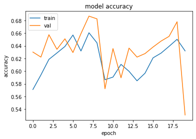

```
Saved model to disk
Test loss: 0.6846112473194416 / Test accuracy: 0.5571153846153846
Accuracy: 0.557115
Precision: 0.556318
Recall: 0.963300
F1 score: 0.705310
```

```python
performance_history(history,model_type,name)
store_model(model_rnn,model_type,name)
model_evaluation(model_rnn,test_text_padded,y_test)
performance_report(model_rnn,test_text_padded,y_test)
```

### Running GRU network

```python
%%time

## Build Network
model_type = 'GRU'
name = "Model_" + str(epochs)+dash+str(batch_size)+dash+str(max_text_length)+dash+str(vocab_size)+dash

model_gru = build_network_GRU(embeding_layer)

model_gru,history_gru = train_model(model_gru,train_text_padded,y_train,test_text_padded, y_test)
```

```
 Building GRU network
_________________________________________________________________
Layer (type)                 Output Shape              Param #
=================================================================
embedding_1 (Embedding)      (None, 100, 100)          20148300
_________________________________________________________________
gru_1 (GRU)                  (None, 100)               60300
_________________________________________________________________
dropout_1 (Dropout)          (None, 100)               0
_________________________________________________________________
dense_1 (Dense)              (None, 32)                3232
_________________________________________________________________
dropout_2 (Dropout)          (None, 32)                0
_________________________________________________________________
dense_2 (Dense)              (None, 1)                 33
=================================================================
Total params: 20,211,865
Trainable params: 63,565
Non-trainable params: 20,148,300
_________________________________________________________________
None
Train on 16640 samples, validate on 4160 samples
Wall time: 6min 16s
```

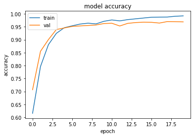

```
Saved model to disk
Test loss: 2.6609848763392523 / Test accuracy: 0.6434615384615384
Accuracy: 0.643462
Precision: 0.689928
Recall: 0.639287
F1 score: 0.663643
```

```python
model_type = 'GRU'
performance_history(history_gru,model_type,name)
store_model(model_gru,model_type,name)
model_evaluation(model_gru,test_text_padded,y_test)
performance_report(model_gru,test_text_padded,y_test)
```

### Running LSTM network

```python
%%time
model_type = 'LSTM'
name = "Model_" + str(epochs)+dash+str(batch_size)+dash+str(max_text_length)+dash+str(vocab_size)+dash

## Build Network
model_lstm = build_network_lstm(embeding_layer,lstm_size)

model_lstm,history_lstm = train_model(model_lstm,train_text_padded,y_train,test_text_padded, y_test)
```

```
 Building Sequential network
_________________________________________________________________
Layer (type)                 Output Shape              Param #
=================================================================
embedding_1 (Embedding)      (None, 100, 100)          20148300
_________________________________________________________________
lstm_2 (LSTM)                (None, 100)               80400
_________________________________________________________________
dropout_7 (Dropout)          (None, 100)               0
_________________________________________________________________
dense_7 (Dense)              (None, 32)                3232
_________________________________________________________________
dropout_8 (Dropout)          (None, 32)                0
_________________________________________________________________
dense_8 (Dense)              (None, 1)                 33
=================================================================
Total params: 20,231,965
Trainable params: 83,665
Non-trainable params: 20,148,300
_________________________________________________________________
None
Train on 16640 samples, validate on 4160 samples
Wall time: 9min 40s
```

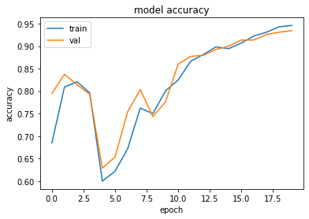

```
Saved model to disk
Test loss: 1.3714693516951342 / Test accuracy: 0.645
Accuracy: 0.645000
Precision: 0.690575
Recall: 0.642782
F1 score: 0.665822
```

```python
performance_history(history_lstm,model_type,name)
store_model(model_lstm,model_type,name)
model_evaluation(model_lstm,test_text_padded,y_test)
performance_report(model_lstm,test_text_padded,y_test)
```

#### Train Model and Evaluate Model

- GRUs are simpler and thus easier to modify, for example adding new gates in case of additional input to the network. It's just less code in general.
- LSTMs should in theory remember longer sequences than GRUs and outperform them in tasks requiring modeling long-distance relations.